# Demo arXiv template

Authors

Affiliations

[Michael J Mahoney](https://mm218.dev)

State University of New York College of Environmental Science and Forestry

Someone Else

State University of New York College of Environmental Science and Forestry

Abstract

This document is only a demo explaining how to use the template.

Keywords

template, demo

# 1 Introduction

This is an example of how to use this template to render journal articles. This template is inspired by the arXiv articles template for rmarkdown, repurposed for the Quarto publishing system.

This quarto extension format supports PDF and HTML outputs. This template is primarily focused on generating acceptable $\LaTeX$ outputs from Quarto, but renders an acceptable HTML output using the standard Quarto options.

# 2 Quarto

# 3 Running Code

This format hide chunks by default, but you can set `echo` option to `true` locally in the chunk:

Table 1: A table.

```
GLM Analysis Results:
          term  estimate  std.error  statistic  p.value
         const    1.4671     0.0169    86.6170      0.0
         Eth_B    1.2621     0.0197    64.1064      0.0
         Sex_M    0.2051     0.0063    32.3999      0.0
       Age_U15    0.2051     0.0063    32.3999      0.0
        Lrn_SL    0.2051     0.0063    32.3999      0.0
   Eth_B:Sex_M    0.0000     0.0000        NaN      NaN
 Eth_B:Age_U15    0.0000     0.0000        NaN      NaN
  Eth_B:Lrn_SL    0.0000     0.0000        NaN      NaN
 Sex_M:Age_U15    0.2051     0.0063    32.3999      0.0
  Sex_M:Lrn_SL    0.2051     0.0063    32.3999      0.0
Age_U15:Lrn_SL    0.2051     0.0063    32.3999      0.0
```

# 4 Markdown Basics

This section of the template is adapted from [Quarto’s documentation on Markdown basics](https://quarto.org/docs/authoring/markdown-basics.html).

## 4.1 Text Formatting

Markdown Syntax

Output

```
*italics* and **bold**
```

*italics* and **bold**

```
superscript^2^ / subscript~2~
```

superscript<sup>2</sup> / subscript<sub>2</sub>

```
~~strikethrough~~
```

strikethrough

```
`verbatim code`
```

`verbatim code`

## 4.2 Headings

Markdown Syntax

Output

```
# Header 1
```

# 5 Header 1

```
## Header 2
```

## 5.1 Header 2

```
### Header 3
```

### 5.1.1 Header 3

## 5.2 Equations

Use `$` delimiters for inline math and `$$` delimiters for display math. For example:

Markdown Syntax

Output

```
inline math: $E = mc^{2}$
```

inline math: $E=mc^{2}$

```
display math:

$$E = mc^{2}$$
```

display math:
$$E = mc^{2}$$

If assigned an ID, display math equations will be automatically numbered:

$$\frac{\partial \mathrm C}{ \partial \mathrm t } + \frac{1}{2}\sigma^{2} \mathrm S^{2}
\frac{\partial^{2} \mathrm C}{\partial \mathrm C^2}
+ \mathrm r \mathrm S \frac{\partial \mathrm C}{\partial \mathrm S}\ =
\mathrm r \mathrm C
\tag{1}$$

## 5.3 Other Blocks

Markdown Syntax

Output

```
> Blockquote
```

> Blockquote

```
| Line Block
|   Spaces and newlines
|   are preserved
```

Line Block  
Spaces and newlines  
are preserved

## 5.4 Cross-references

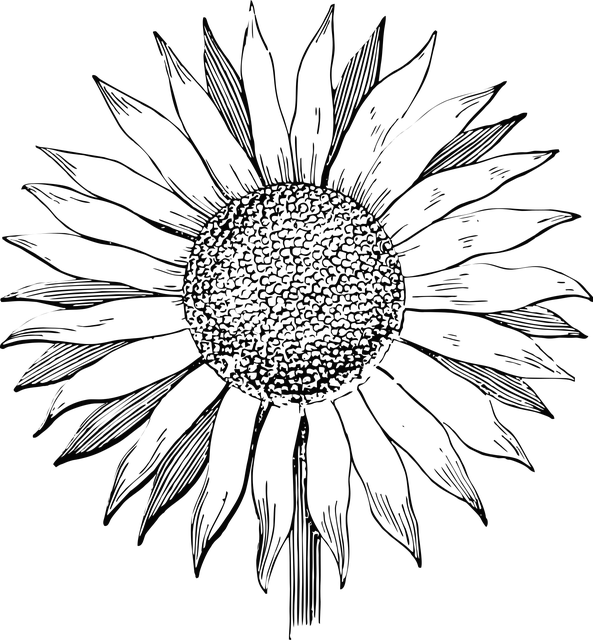

Figure 1: A sunflower

Markdown Format

Output

```
@fig-sunflower is pretty.
```

Figure 1 is pretty.

```
@tbl-glm was created from code.
```

Table 1 was created from code.

```
@sec-crf is this section.
```

Section 5.4 is this section.

```
@eq-black-scholes is above.
```

Equation 1 is above.

See the [Quarto documentation on cross-references for more](https://quarto.org/docs/authoring/cross-references.html).

## 5.5 Citation Syntax

Quarto uses the standard Pandoc markdown representation for citations. Here are some examples:

Markdown Format

Output

```
Blah Blah [see @knuth1984, pp. 33-35;
also @wickham2015, chap. 1]
```

Blah Blah see [1, pp. 33–35], also [2, Ch. 1]

```
Blah Blah [@knuth1984, pp. 33-35,
38-39 and passim]
```

Blah Blah [1, pp. 33–35, 38–39] and passim

```
Blah Blah [@wickham2015; @knuth1984].
```

Blah Blah [1], [2].

```
Wickham says blah [-@wickham2015]
```

Wickham says blah [2]

You can also write in-text citations, as follows:

Markdown Format

Output

```
@knuth1984 says blah.
```

[1] says blah.

```
@knuth1984 [p. 33] says blah.
```

[1, p. 33] says blah.

See the [Pandoc Citations](https://pandoc.org/MANUAL.html#citations) documentation for additional information on citation syntax.

To provide a custom citation stylesheet, provide a path to a CSL file using the `csl` metadata field in your document, for example:

```yaml
---
title: "My Document"
bibliography: references.bib
csl: nature.csl
---
```

# References

[1]

D. E. Knuth, “Literate programming,” *The Computer Journal*, vol. 27, no. 2, pp. 97–111, 1984.

[2]

H. Wickham, *R packages*, 1st ed. O’Reilly Media, Inc., 2015.